# table output

ROBERTS

THOMAS

ALITO

SOTOMAYOR

KAGAN

GORSUCH

KAVANAUGH

BARRETT

JACKSON

Case

Docket

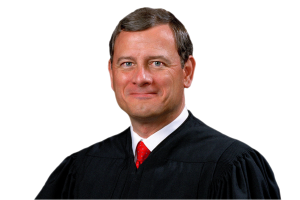

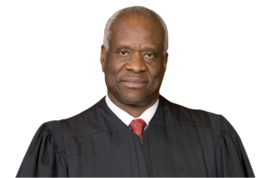

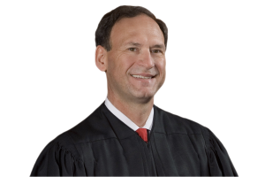

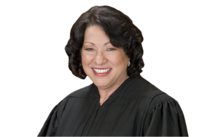

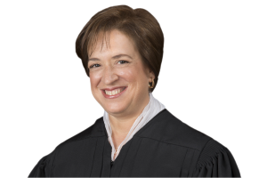

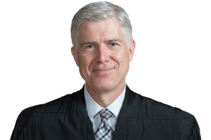

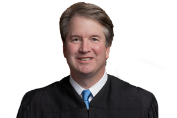

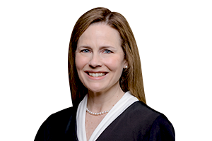

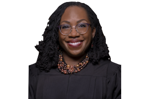

T. M. v. University of Md. Medical System Corporation

25-197

JD

RC

M

M*

JD

JD

M

D

M

McCarthy v. Hernandez

25-748

M

M

M

WNGC

WNGC

M

M

M

WNGC

Cisco Systems, Inc. v. Doe

24-856

M

M

M

D

JD

M

M

M*

SC-JD

M

M

M

JD

D

M

M*

M

JD

Landor v. Louisiana Dept of Corrections and Public Safety

23-1197

M

M

M

JD

JD

M*

M

M

D

Pung v. Isabella County

25-95

M

SC

M*

RC

M

JSC

M

M

JRC

Blanche v. Lau

25-429

M

M*

M

JD

JD

M

M

M

D

Monsanto v. Durnell

24-1068

M

RC

M

M

M

JD

M*

M

D

Wolford v. Lopez

24-1046

M

JRC

M*

JD

D

JRC

M

RC

D

Mullin v. Al Otro Lado

25-5

M

RC

M*

D

JD

M

M

M

D-JD

Mullin v. Doe

25-1083

M

RC

M*

JD

D

M

M

M

JD

Watson v. Republican National Committee

24-1260

M

JD

D

M

M

JD

JD

M*

M

M* = Majority Author M = Joined Majority RC = Wrote Concurrence JRC = Joined Concurrence RC-JRC = Wrote & Joined Concurrence

CJ = Wrote Concurrence In Judgement JCJ = Joined Concurrence In Judgement SC = Wrote Special Concurrence JSC = Joined Special Concurrence

D = Wrote Dissent JD = Joined Dissent D-JD = Wrote & Joined Dissent